# ***REMOVED*** Proteomic and Phosphoproteomic Analysis

Brett Engelmann(Integrative Proteomics)

March 15th, 2019

# Overview

The purpose of this project is to ‘Discern differences in signaling between normal fibroblasts vs. their transformed cancer-associated counterparts in an effort to articulate underpinning biology that may be exploited for pharmaceutical intervention.’ Human donor fibroblasts from two normal and two cancer-associated **breast** tissues were cultured at ABR to approximately 15 million cells per donor, scraped from cell culture dish with Accutase containing 1x PhosSTOP, then divided into three aliquots of 5 million cells. Cells were pelleted and washed twice with 1x PhosSTOP in PBS. Final cell pellets were flash frozen and kept at -80 C until arriving at MS Bioworks for phosphoproteomics sample workup. Replicates can be considered ‘technical’, in that they incompass repeated, separate applications of the phosphoproteomic enrichment and LC-MS protocol. 12 proteomic and 12 phosphoproteomic samples were processed with 4 and 2 hour RP-HPLC gradients respectively.

These data were processed with maxquant/andromeda (V 1.6.0.16) on 2/1/19 using a human coding sequence (CCDS) ~35,000 sequences) `Homo_sapiens.GRCh38.84.pep.all.parsedCCDS.fa` database retrieved from Ensembl in May of 2016. A common contaminants list was appended to this `FASTA` to facilitate their exclusion. The mq parameters file `mqpar2_4_19` in this directory has all the MQ parameter choices.

Some key MaxQuant processing parameters:

- FixedMod = Carbamidomethyl
- VarMod = Oxidation(M); Acetyl (Protein N-term); Phospho (STY) (for appropriate samples)
- PSM/Protein/Site FDR = .01 using reverted database as decoys
- The match-between-runs (MBR) feature was enabled
- Label free quantification (MQ-LFQ) on XICs was employed

Below I analyze the data from the project. Specifically, I assess coverage and quality, transform and normalize the data, perform EDA, impute, and batch effect correct the data. Then, I construct the proper statistical models for differential phosphorylation analysis. Then, I perform a series of enrichment analyses on the data using appropriate ontologies. Finally, the results are exported in a format suitable for web-application deployment.

# Proteome & Phosphoproteome QC

## Proteome QC stats

### Protein Data Types

Bar diagram of proteins identified, quantified, and quantified with **at least** one matching phosphopeptide.

[figure not shown]

### Proteomic Sampling Depth

Running protein count by iBAQ (sum of all peptide intensities divided by the number of theoretical tryptic peptides for a protein) gives reveals a sampling depth of 6 orders of magnitude.

[figure not shown]

## Phosphopeptide QC stats

### Phosphosite Breakdown

Breakdown of phosphosites by AA and multiplicity is as expected

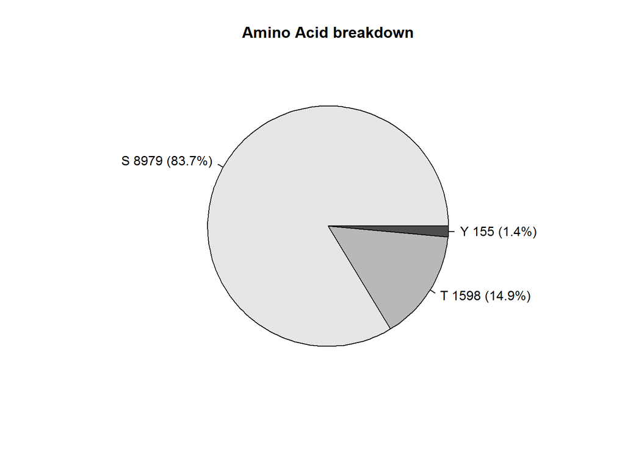

[figure not shown]

Most phosphosites are observed as singletons.

[figure not shown]

### Phosphosite Data Types

MQ outputs a `Phospho (STY)Sites` summary table that gives all *sites* within a protein that are identified. Singly, doubly, and triply phosphorylated peptides that map/localize to this site are quantified. “Class 1” sites (C1) are sites with median localiztion probability ~.95 and minimum localization probability of .75.

10732 sites were identified in at least one sample at an FDR of 1%. A breakdown of phoshposites by identification, quantification, and localization probability:

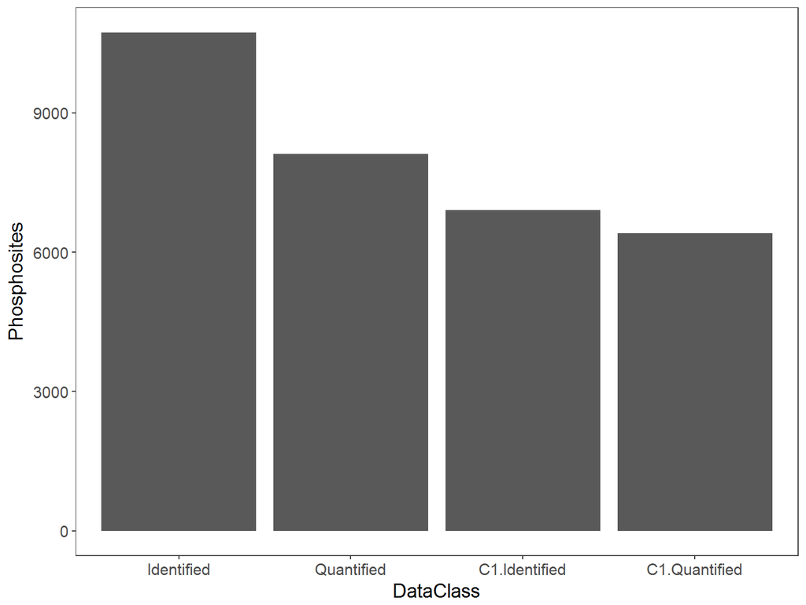

# Exploratory Data Analysis

## Proteome

### Boxplots & Heatmaps

3520 protein groups were identified in at least one sample. Here I log2 transform LFQ Intensity values for the 12 samples. Boxplot and pearson correlation of replicate experiments are shown below.

[figure not shown]

[interactive chart not shown]

### Normalization

The data are median and quantile normalized.

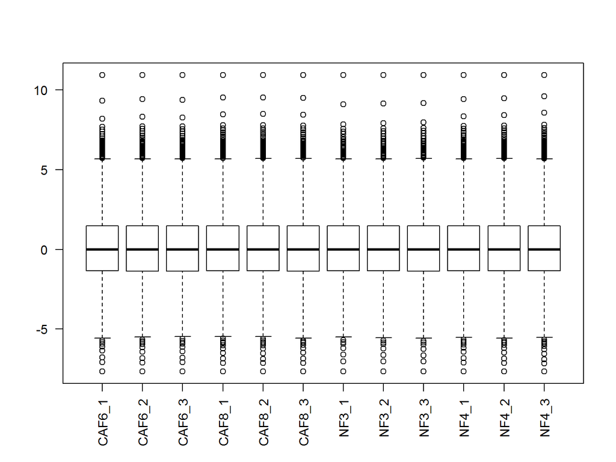

The pairwise correlations are roughly the same following normalization.

[interactive chart not shown]

## Phosphoproteome

### Boxplots & Heatmaps

6794 class 1 quantified phowphopeptides were identified in at least one sample and 1017 were quantified in all samples. Log2 transform XIC Intensity values for the 12 samples. Boxplot and and pearson correlation of replicate experiments are shown below.

[figure not shown]

[interactive chart not shown]

### Normalization

The data are median and quantile normalized.

[figure not shown]

The pairwise correlations are roughly the same following normalization.

[interactive chart not shown]

## Principal Components Analysis

```
## [1] TRUE
```

```
## [1] TRUE
```

```
## [1] TRUE
```

```
## [1] TRUE
```

### Proteome

Donor technical replicates so some clustering but there is not much segregation. NF3 is a clear outlier.

[figure not shown]

### Phosphoproteome

While NF3 is still a clear outlier, phosphoproteome donor technical replicates now cluster together.

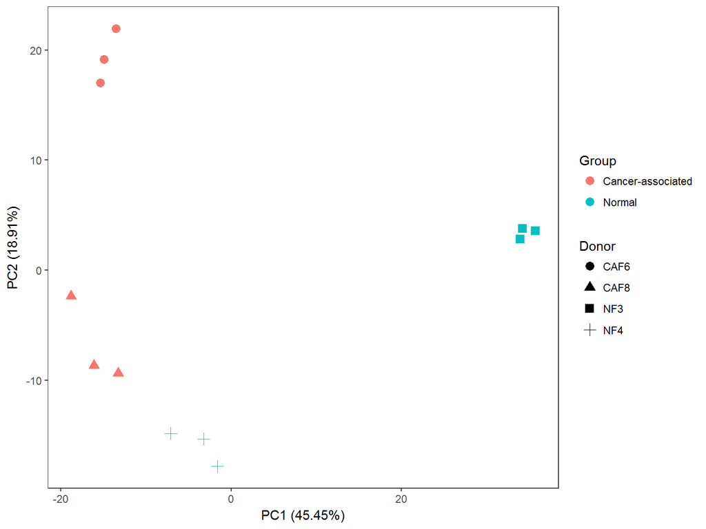

# Imputation

## Proteome

3520 proteins were measred in at least one sample. **Only 904 are truly observed in each of the samples**. Here I will impute across all samples. Imputation is cached because I cannot manually set the random number seed.

```
## Cluster size 3520 broken into 2874 646
## Cluster size 2874 broken into 2273 601
## Cluster size 2273 broken into 182 2091
## Done cluster 182
## Cluster size 2091 broken into 278 1813
## Done cluster 278
## Cluster size 1813 broken into 322 1491
## Done cluster 322
## Done cluster 1491
## Done cluster 1813
## Done cluster 2091
## Done cluster 2273
## Done cluster 601
## Done cluster 2874
## Done cluster 646
```

### PCA of imputed data across all samples

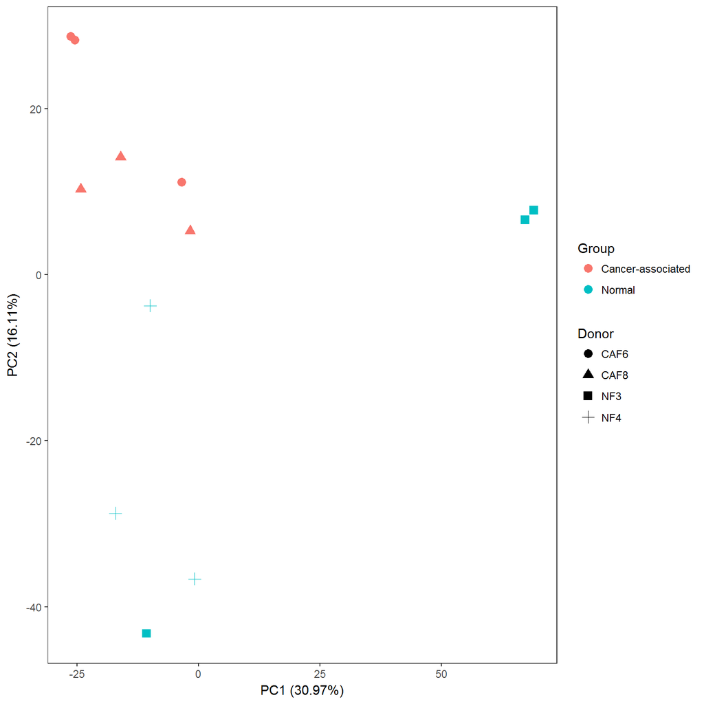

## Phosphoproteome

```
## Cluster size 6764 broken into 5625 1139
## Cluster size 5625 broken into 1929 3696
## Cluster size 1929 broken into 1164 765
## Done cluster 1164
## Done cluster 765
## Done cluster 1929
## Cluster size 3696 broken into 1296 2400
## Done cluster 1296
## Cluster size 2400 broken into 841 1559
## Done cluster 841
## Cluster size 1559 broken into 1093 466
## Done cluster 1093
## Done cluster 466
## Done cluster 1559
## Done cluster 2400
## Done cluster 3696
## Done cluster 5625
## Done cluster 1139
```

### PCA of imputed data across all samples

[figure not shown]

# Model Definition

We would like to identify differentially expressed proteins and differentially phosphorylated peptides across donors.

> “All models are wrong but some are useful” - George Box

Ideally, a single linear mixed-effects model would be used to test for differences between normal and cancer associated fibroblasts. I have tried this and, due to the underpowered design (their are only two samples in each condition), I do not find and differential expression with such a model. Therefore, I have moved forward with a model to test for differences across donors.

This model will be applied on the:

- proteome
- phosphoproteome
- proteome normalized phosphoproteome

## Model

Linear regression model with surrogate variables (estimated separately) added as covariates:

$$Y_{jk} = Donor_{j} + SV_l + {\epsilon}_{jk}: j=3,4,6,8; k = 1,2,3; l=1,...,N$$
where $Y_{jk}$ is logged protein, phosphosite, or protein-normalized-phosphosite intensity of technical replicate k from firbroblast donor j. $Donor_{j}$ is the estimated effect from donor j and $SV_k$ is the estimated fixed effect from a covariate ‘surrogate variable’ l identified from the data (see below).

## Heuristic

For a protein/phosphopeptide to be analyzed it needs to be observed at least once per donor.

**3024** phosphopeptides and **1419** protein groups satisfy either of the above conditions. The `MedianQuantiledImputed.passed` and `MedianQuantiledProteinImputed.passed` data frames are used for modeling. The corresponding binary data frames have the logical results of the heuristic test associated with each peptide. The peptides that do not pass the test have been removed.

### Combined Data

on hold

# Latent variation correction with SVA

Here I attempt to correct for unwanted latent sources of variation with **surrogate variable analysis (SVA)**, a popular form of weighted factor analysis. I have protected donor (see section above for more details on each model) with a fixed effects regression model. Here I use the **complete cases** from each molecular phenotype.

## Proteome

Here I work with the `MedianQuantiledProteinCompleteCases` dataframe to identifiy factors not associated with donor.

```
## [1] TRUE
```

```
## Number of significant surrogate variables is:  2
## Iteration (out of 5 ):1  2  3  4  5
```

2 surrogate variables were identified. Below are the PCA plots before and after regressing away the surrogate variables on the 904 complete cases. After surrogate variable regression, the effect of the one outlier sample is addressed and the donors cluster together. In both cases PC1 is seems to be explained by the difference between donor 3 and the other donors.

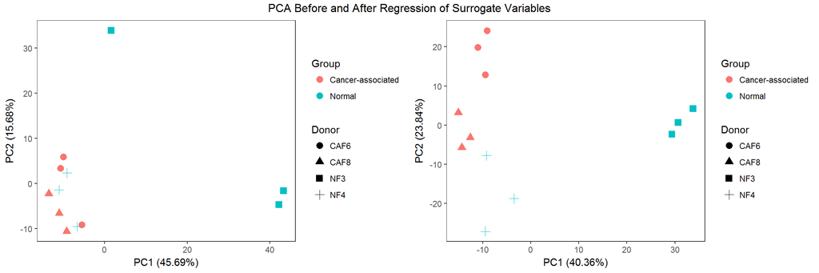

## Phosphoproteome

Here I work with the 1017 phosphosite intensities from the `MedianQuantiledCompleteCases` dataframe to identifiy factors not associated with donor.

```
## [1] TRUE
```

```
## Number of significant surrogate variables is:  2
## Iteration (out of 5 ):1  2  3  4  5
```

Again, 2 surrogate variables were identified. Below are the PCA plots before and after regressing away the surrogate variables on the 1017 complete cases. After surrogate variable regression, the donors cluster a bit closer together. In both cases PC1 is seems to be explained by the difference between donor 3 and the other donors (consistent with the proteomic data).

[figure not shown]

# Inference

Differential protein expression and phosphorylation is performed within the `limma` framework. In all cases `eBayes` is run with `robust=TRUE` to deal with hypervariable genes.

## Proteome

**1419** proteins were ultimately fit to the model (see Model Definition above). The two SVs identified above were included as covariates. Six contrasts (comparisons between donors) were examined.

```
## [1] TRUE
```

A few EDA plots show no obvious artifacts associated with this analysis. However, the plot of the model fit residuals vs average log expression (last plot) indicates an intensity dependent trend, that could lead to protein expression dependent diffexp calls. This trend was accounted for in `limma` by fitting with a prior variance (eBayes trend=TRUE) intensity distribution trend estimated by the average log expression and therefore any bias related to protein expression should be driven by biology.

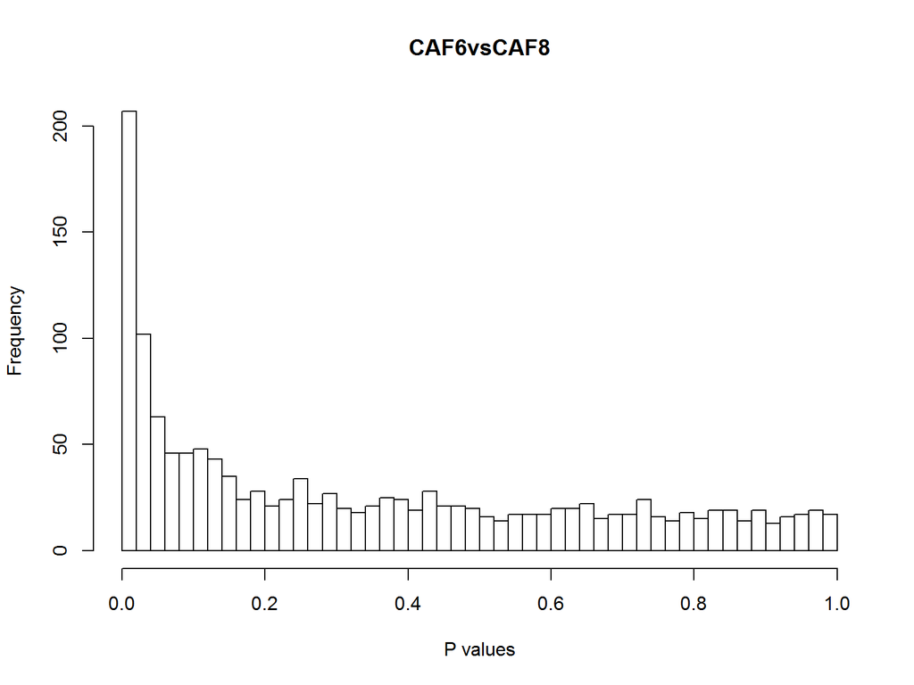

[figure not shown]

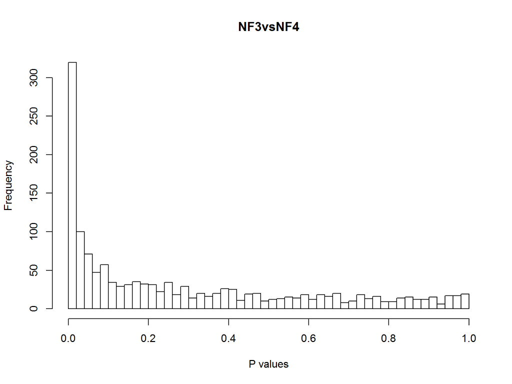

[figure not shown]

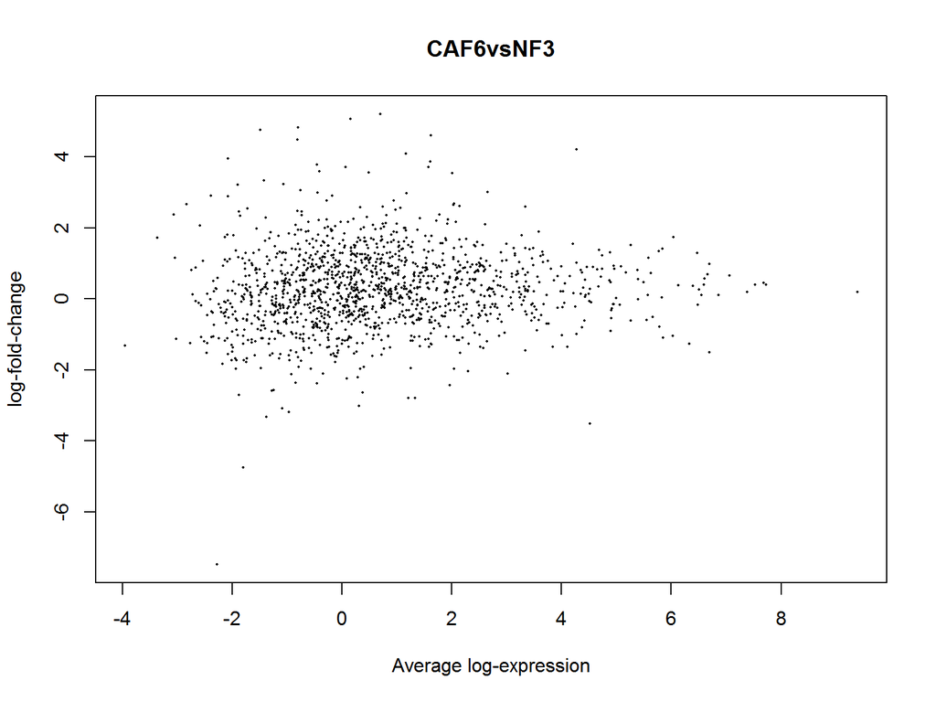

[figure not shown]

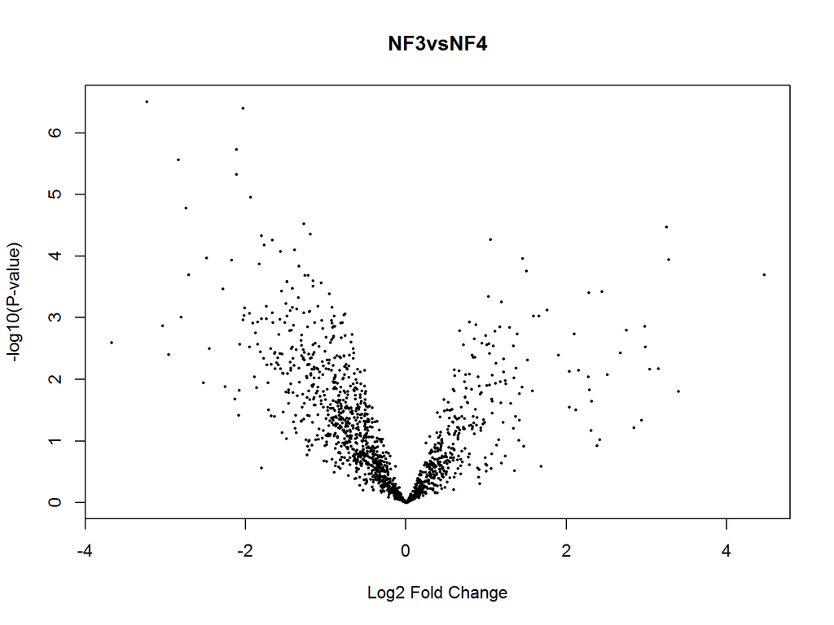

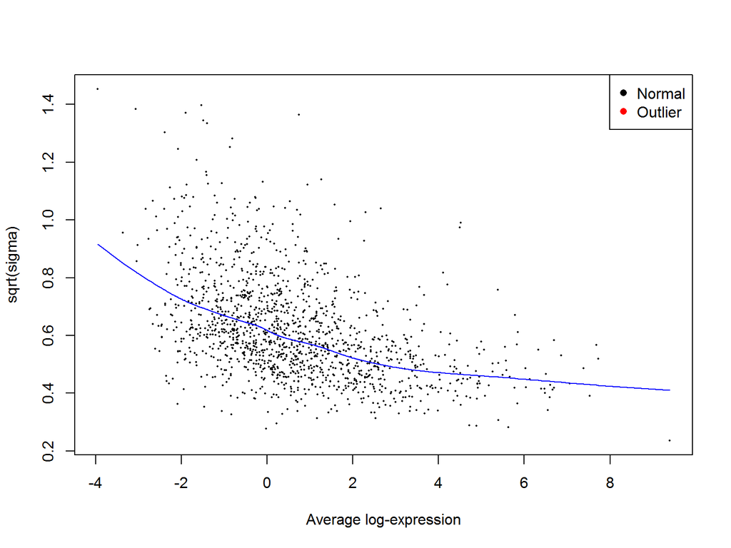

### Example plot

Below is the peptide with the lowest p-value testing the null hypothesis that there is no difference in phosphosite levels between ***REMOVED***6 and ***REMOVED***8. Here, `id = 1825` is used with the `SV.regressed.protein` and `binary.frame.protein.passed` data frames.

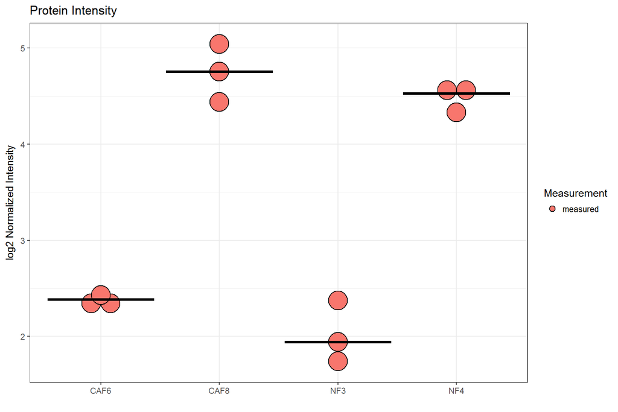

## Phosphoproteome

**3024** phosphopeptides*(mostly) were ultimately fit to the model (see Model Definition above). The two SVs identified above were included as covariates. Six contrasts (comparisons between donors) were examined.

```
## [1] TRUE
```

A few EDA plots show no obvious artifacts associated with differential phosphorylation analysis.

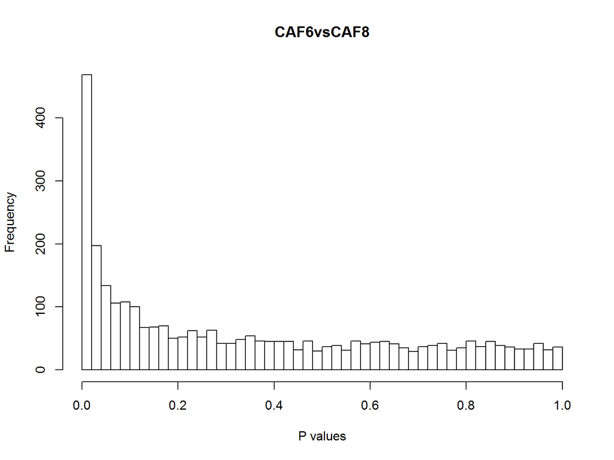

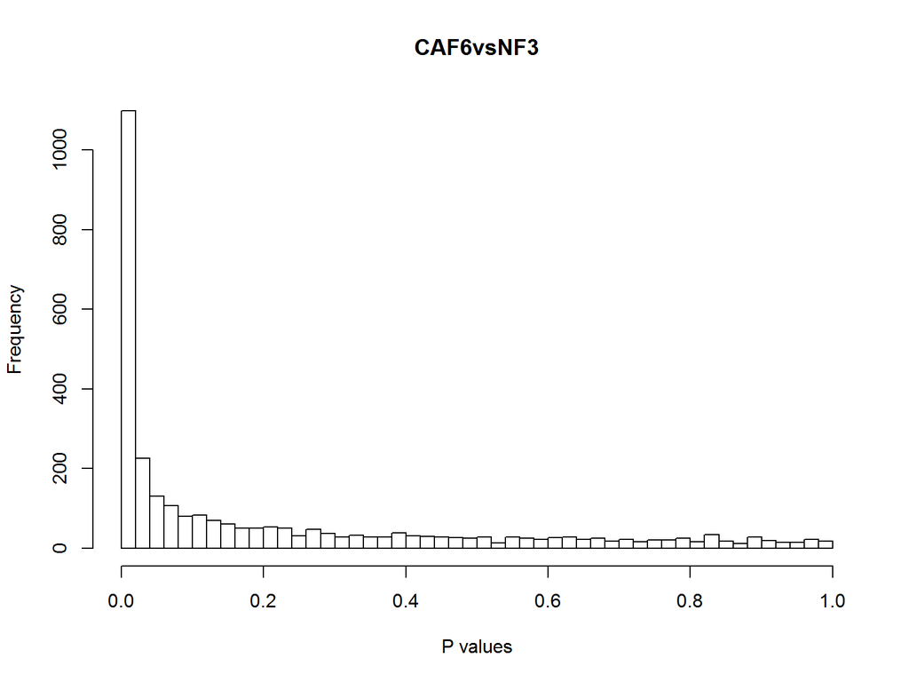

[figure not shown]

### Example plot

Below is the peptide with the lowest p-value testing the null hypothesis that there is no difference in phosphosite levels between ***REMOVED***6 and ***REMOVED***8. Here, `idmult = 9382_2` is used with the `SV.regressed.phospho` and `binary.frame.phospho.passed` data frames.

[figure not shown]

# Enrichment Analysis

Enrichment analysis is performed on protein and phospho data. Reactome, GO(bp,mf,cc, slim) and CORUM are applied. Within each ontology, every annotation must be represented at least three times in the dataset to be considered for enrichment analysis.

# Data Export

Exported:

1. The median, quantile normalized, imputed (across all samples) and SV regressed, protein and phosphopeptide XICs
2. The MS meta data and other identifiers associated with each protein and site
3. A binary matrix indicating if a data point was measured (1) or imputed (0) for protein and phosphosites
4. Study meta data
5. Inference test results
6. Enrichment analysis results and indices

Note that for phoshoproteome data, numbers 1 and 2 are combined into a single table `SiteTableCombined`. This `SiteTableCombined` table has a ‘dupidmult’ column for duplicated quantifications that account for doubly or triply phosphorylated peptides mapping to mulitple sites. Numbers 3 and 4 are single tables. 4 may or may not be available. 5 and 6 are exported in binary format that I will use for package construction. All of this data will be used with the the [app](http://go/phospho).

**note that multiply phosphorylated peptides are only represented once and therefore in such cases the site of modification is not unique**

The key for annotation mergining is the ENSP identifier in the ‘protein’ column. HGNC symbols that map to protein ENSPs are sourced from biomart ensembl84 database. Currently, Mark Ciaccio’s netmed database is also being used. **note that some proteins do not have mapped HGNC symbols**